# Description

# Data Compatibily Adjustment

## Encoding the target labels

```python
# Convert labels from names to one hot vectors.
# We have already used encoding methods like onehotencoder and labelencoder earlier so now we will be using a new encoding method called labelBinarizer.
# Labelbinarizer works similar to onehotencoder

from sklearn.preprocessing import LabelBinarizer
enc = LabelBinarizer()
y_train_encoded = enc.fit_transform(y_train)
y_test_encoded=enc.transform(y_test)
```

```python
print(X_train.shape,y_train_encoded.shape)
print(X_test.shape,y_test_encoded.shape)
```

```
(4275, 128, 128, 3) (4275, 12)
(475, 128, 128, 3) (475, 12)
```

- **Data has already been reshaped into shapes compatible with Keras models. Thus, data transformation is compatible and fit for modelling**
- **Data is in the proper shape to be Modelled using CNN and other Computer Vision Architectures**

# Model Building

```python
# Clearing backend
from tensorflow.keras import backend
backend.clear_session()
```

```python
# Fixing the seed for random number generators
import random
np.random.seed(1)
random.seed(1)
tf.random.set_seed(1)
```

```python
# Intializing a sequential model
model = Sequential()

# Adding first conv layer with 64 filters and kernel size 3x3 , padding 'same' provides the output size same as the input size
# Input_shape denotes input image dimension of images
model.add(Conv2D(64, (3, 3), activation='relu', padding="same", input_shape=(128, 128, 3)))

# Adding max pooling to reduce the size of output of first conv layer
model.add(MaxPooling2D((2, 2), padding = 'same'))

model.add(Conv2D(32, (3, 3), activation='relu', padding="same"))
model.add(MaxPooling2D((2, 2), padding = 'same'))

# flattening the output of the conv layer after max pooling to make it ready for creating dense connections
model.add(Flatten())

# Adding a fully connected dense layer with 100 neurons
model.add(Dense(32, activation='relu'))
model.add(Dropout(0.2))
# Adding the output layer with 12 neurons and activation functions as softmax since this is a multi-class classification problem
model.add(Dense(12, activation='softmax'))

# Using SGD Optimizer
# opt = SGD(learning_rate=0.01, momentum=0.9)
opt = Adam(learning_rate = 0.002,beta_1=0.9,beta_2=0.999,epsilon=0.1,decay=0.0)
# Compile model
model.compile(optimizer=opt, loss='categorical_crossentropy', metrics=['accuracy'])

# Generating the summary of the model
model.summary()
```

```
Model: "sequential"
_________________________________________________________________
 Layer (type)                Output Shape              Param #
=================================================================
 conv2d (Conv2D)             (None, 128, 128, 64)      1792

 max_pooling2d (MaxPooling2D  (None, 64, 64, 64)       0
 )

 conv2d_1 (Conv2D)           (None, 64, 64, 32)        18464

 max_pooling2d_1 (MaxPooling  (None, 32, 32, 32)       0
 2D)

 flatten (Flatten)           (None, 32768)             0

 dense (Dense)               (None, 32)                1048608

 dropout (Dropout)           (None, 32)                0

 dense_1 (Dense)             (None, 12)                396

=================================================================
Total params: 1,069,260
Trainable params: 1,069,260
Non-trainable params: 0
_________________________________________________________________
```

## Fitting the Model on the data

```python
#Importing classback API
from keras import callbacks

es_cb = callbacks.EarlyStopping(monitor='val_loss', min_delta=0.001, patience=5)

history_1 = model.fit(
            X_train, y_train_encoded,
            epochs=100,
            validation_split=0.1,
            # shuffle=True,
            batch_size=64,
            verbose=1,
            callbacks=[es_cb]
)
```

## Model Evaluation

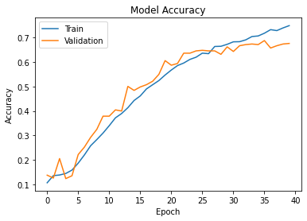

```python
plt.plot(history_1.history['accuracy'])
plt.plot(history_1.history['val_accuracy'])
plt.title('Model Accuracy')
plt.ylabel('Accuracy')
plt.xlabel('Epoch')
plt.legend(['Train', 'Validation'], loc='upper left')
plt.show()
```

- The Model is generalizing well

## Evaluating the model on test data

```python
accuracy = model.evaluate(X_test, y_test_encoded, verbose=2)
```

```
15/15 - 0s - loss: 0.9832 - accuracy: 0.6926 - 461ms/epoch - 31ms/step
```

## Generating the predictions using test data

```python
# Here we would get the output as probablities for each category
y_pred=model.predict(X_test)
```

```python
y_pred
```

```
array([[7.15399509e-08, 1.25093687e-08, 1.19366475e-10, ...,
        1.08002592e-03, 1.00997113e-06, 4.34307428e-03],
       [6.97779112e-10, 4.21521673e-03, 1.18342745e-04, ...,
        6.15436910e-03, 9.89464283e-01, 6.77373961e-08],
       [5.25921996e-06, 5.96010545e-03, 8.33245285e-04, ...,
        8.49265978e-03, 9.82672215e-01, 9.45567808e-06],
       ...,
       [2.58112073e-01, 6.80903227e-08, 6.13026277e-05, ...,
        2.42429650e-07, 1.90792548e-07, 6.31284260e-04],
       [9.08621951e-06, 5.13071660e-03, 1.62401963e-02, ...,
        1.41271487e-01, 6.97152223e-04, 3.20520904e-03],
       [2.49779405e-05, 2.82574892e-02, 1.40712097e-01, ...,
        2.43643239e-01, 5.42802334e-01, 5.93165227e-04]], dtype=float32)
```

## Plotting the confusion Matrix

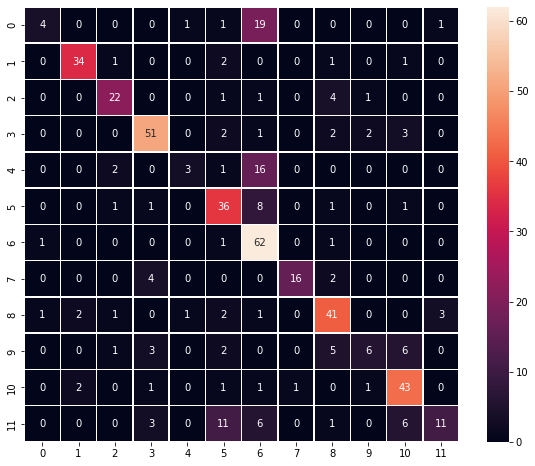

```python
# Obtaining the categorical values from y_test_encoded and y_pred
y_pred_arg=np.argmax(y_pred,axis=1)
y_test_arg=np.argmax(y_test_encoded,axis=1)

# Plotting the Confusion Matrix using confusion matrix() function which is also predefined tensorflow module
confusion_matrix = tf.math.confusion_matrix(y_test_arg,y_pred_arg)
f, ax = plt.subplots(figsize=(10, 8))
sns.heatmap(
    confusion_matrix,
    annot=True,
    linewidths=.4,
    fmt="d",
    square=True,
    ax=ax
)

plt.show()
```

# Model Performance Improvement

## Model 2 - Data Augumentation

In most of the real-world case studies, it is challenging to acquire a large number of images and then train CNNs. To overcome this problem, one approach we might consider is Data Augmentation. CNNs have the property of translational invariance, which means they can recognise an object even if its appearance shifts translationally in some way.

Taking this attribute into account, we can augment the images using the techniques listed below -

1. Horizontal Flip (should be set to True/False)
2. Vertical Flip (should be set to True/False)
3. Height Shift (should be between 0 and 1)
4. Width Shift (should be between 0 and 1)
5. Rotation (should be between 0 and 180)
6. Shear (should be between 0 and 1)
7. Zoom (should be between 0 and 1) etc.

Remember, data augmentation should not be used in the validation/test data set.

```python
# Clearing backend
from tensorflow.keras import backend
backend.clear_session()

# Fixing the seed for random number generators
import random
np.random.seed(1)
random.seed(1)
tf.random.set_seed(1)
```

```python
# All images to be rescaled by 1/255.
train_datagen = ImageDataGenerator(
                              rotation_range=20,
                              fill_mode='nearest'
                              )
```

```python
# Intializing a sequential model
model = Sequential()

# Adding first conv layer with 64 filters and kernel size 3x3 , padding 'same' provides the output size same as the input size
# Input_shape denotes input image dimension images
model.add(Conv2D(64, (3, 3), activation='relu', padding="same", input_shape=(128, 128, 3)))

# Adding max pooling to reduce the size of output of first conv layer
model.add(MaxPooling2D((2, 2), padding = 'same'))
# model.add(BatchNormalization())
model.add(Conv2D(32, (3, 3), activation='relu', padding="same"))
model.add(MaxPooling2D((2, 2), padding = 'same'))
model.add(BatchNormalization())
# flattening the output of the conv layer after max pooling to make it ready for creating dense connections
model.add(Flatten())

# Adding a fully connected dense layer with 100 neurons
model.add(Dense(32, activation='relu'))
model.add(Dropout(0.2))
# Adding the output layer with 10 neurons and activation functions as softmax since this is a multi-class classification problem
model.add(Dense(12, activation='softmax'))

# Using SGD Optimizer
# opt = SGD(learning_rate=0.01, momentum=0.9)
opt = Adam(learning_rate = 0.002,beta_1=0.9,beta_2=0.999,epsilon=0.1,decay=0.0)
# Compile model
model.compile(optimizer=opt, loss='categorical_crossentropy', metrics=['accuracy'])

# Generating the summary of the model
model.summary()
```

```
Model: "sequential"
_________________________________________________________________
 Layer (type)                Output Shape              Param #
=================================================================
 conv2d (Conv2D)             (None, 128, 128, 64)      1792

 max_pooling2d (MaxPooling2D  (None, 64, 64, 64)       0
 )

 conv2d_1 (Conv2D)           (None, 64, 64, 32)        18464

 max_pooling2d_1 (MaxPooling  (None, 32, 32, 32)       0
 2D)

 batch_normalization (BatchN  (None, 32, 32, 32)       128
 ormalization)

 flatten (Flatten)           (None, 32768)             0

 dense (Dense)               (None, 32)                1048608

 dropout (Dropout)           (None, 32)                0

 dense_1 (Dense)             (None, 12)                396

=================================================================
Total params: 1,069,388
Trainable params: 1,069,324
Non-trainable params: 64
_________________________________________________________________
```

```python
#Importing classback API
from keras import callbacks

es_cb = callbacks.EarlyStopping(monitor='val_loss', min_delta=0.001, patience=4)

# Epochs
epochs = 25
# Batch size
batch_size = 64

history = model.fit(train_datagen.flow(X_train,y_train_encoded,
                                       batch_size=batch_size,
                                       seed=1,
                                       shuffle=False),
                    epochs=epochs,
                    steps_per_epoch=X_train.shape[0] // batch_size,
                    validation_data=(X_test,y_test_encoded),
                    verbose=1,
                    # callbacks=[es_cb]
                    )
```

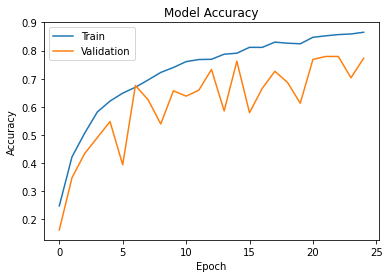

```python
plt.plot(history.history['accuracy'])
plt.plot(history.history['val_accuracy'])
plt.title('Model Accuracy')
plt.ylabel('Accuracy')
plt.xlabel('Epoch')
plt.legend(['Train', 'Validation'], loc='upper left')
plt.show()
```

## Evaluating the model on test data

```python
accuracy = model.evaluate(X_test, y_test_encoded, verbose=2)
```

```
15/15 - 0s - loss: 0.6933 - accuracy: 0.7726 - 123ms/epoch - 8ms/step
```

## Generating the predictions using test data

```python
# Here we would get the output as probablities for each category
y_pred=model.predict(X_test)
```

```python
y_pred
```

```
array([[1.6579632e-08, 6.6373738e-09, 7.5267947e-10, ..., 5.9496360e-05,
        3.1827432e-07, 7.0342426e-06],
       [1.1041151e-09, 6.9162957e-03, 5.1302859e-04, ..., 1.0652242e-03,
        9.9134225e-01, 9.5032254e-07],
       [2.1004087e-08, 1.1995215e-06, 1.5271579e-04, ..., 9.1364775e-05,
        9.9707079e-01, 6.2971348e-09],
       ...,
       [9.0583682e-02, 5.0821819e-11, 1.4923510e-08, ..., 5.6100280e-09,
        1.3878617e-09, 6.5875756e-06],
       [5.2249699e-05, 1.7125982e-05, 1.3065372e-04, ..., 1.9676971e-01,
        2.2889259e-03, 1.1722099e-02],
       [3.6428748e-06, 1.8548165e-02, 5.0400954e-02, ..., 3.2535989e-02,
        8.9177543e-01, 8.8615969e-05]], dtype=float32)
```

## Plotting the confusion Matrix

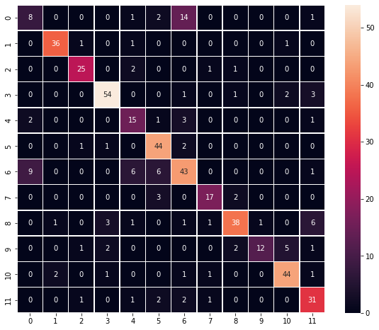

```python
# Obtaining the categorical values from y_test_encoded and y_pred
y_pred_arg=np.argmax(y_pred,axis=1)
y_test_arg=np.argmax(y_test_encoded,axis=1)

# Plotting the Confusion Matrix using confusion matrix() function which is also predefined tensorflow module
confusion_matrix = tf.math.confusion_matrix(y_test_arg,y_pred_arg)
f, ax = plt.subplots(figsize=(10, 8))
sns.heatmap(
    confusion_matrix,
    annot=True,
    linewidths=.4,
    fmt="d",
    square=True,
    ax=ax
)

plt.show()
```

- Class 6 was highly misclassified by the Model

## Model 3 - Transfer Learning using VGG16

```python
# Clearing backend
from tensorflow.keras import backend
backend.clear_session()

# Fixing the seed for random number generators
import random
np.random.seed(1)
random.seed(1)
tf.random.set_seed(1)
```

```python
from tensorflow.keras.models import Model
from keras.applications.vgg16 import VGG16

vgg_model = VGG16(weights='imagenet', include_top = False, input_shape = (128,128,3))
vgg_model.summary()
```

```
Downloading data from https://storage.googleapis.com/tensorflow/keras-applications/vgg16/vgg16_weights_tf_dim_ordering_tf_kernels_notop.h5
Model: "vgg16"
_________________________________________________________________
 Layer (type)                Output Shape              Param #
=================================================================
 input_1 (InputLayer)        [(None, 128, 128, 3)]     0

 block1_conv1 (Conv2D)       (None, 128, 128, 64)      1792

 block1_conv2 (Conv2D)       (None, 128, 128, 64)      36928

 block1_pool (MaxPooling2D)  (None, 64, 64, 64)        0

 block2_conv1 (Conv2D)       (None, 64, 64, 128)       73856

 block2_conv2 (Conv2D)       (None, 64, 64, 128)       147584

 block2_pool (MaxPooling2D)  (None, 32, 32, 128)       0

 block3_conv1 (Conv2D)       (None, 32, 32, 256)       295168

 block3_conv2 (Conv2D)       (None, 32, 32, 256)       590080

 block3_conv3 (Conv2D)       (None, 32, 32, 256)       590080

 block3_pool (MaxPooling2D)  (None, 16, 16, 256)       0

 block4_conv1 (Conv2D)       (None, 16, 16, 512)       1180160

 block4_conv2 (Conv2D)       (None, 16, 16, 512)       2359808

 block4_conv3 (Conv2D)       (None, 16, 16, 512)       2359808

 block4_pool (MaxPooling2D)  (None, 8, 8, 512)         0

 block5_conv1 (Conv2D)       (None, 8, 8, 512)         2359808

 block5_conv2 (Conv2D)       (None, 8, 8, 512)         2359808

 block5_conv3 (Conv2D)       (None, 8, 8, 512)         2359808

 block5_pool (MaxPooling2D)  (None, 4, 4, 512)         0

=================================================================
Total params: 14,714,688
Trainable params: 14,714,688
Non-trainable params: 0
_________________________________________________________________
```

```python
# Making all the layers of the VGG model non-trainable. i.e. freezing them
for layer in vgg_model.layers[:15]:
    layer.trainable = False
```

```python
new_model = Sequential()

# Adding the convolutional part of the VGG16 model from above
new_model.add(vgg_model)

# Flattening the output of the VGG16 model because it is from a convolutional layer
new_model.add(Flatten())

# Adding a dense output layer
new_model.add(Dense(1024, activation='relu'))
new_model.add(Dropout(0.3))
new_model.add(Dense(256, activation='relu'))
new_model.add(Dropout(0.2))
new_model.add(Dense(12, activation='softmax'))
opt = Adam(learning_rate = 0.002,beta_1=0.9,beta_2=0.999,epsilon=0.1,decay=0.0)
# Compile model
new_model.compile(optimizer=opt, loss='categorical_crossentropy', metrics=['accuracy'])

# Generating the summary of the model
new_model.summary()
```

```
Model: "sequential"
_________________________________________________________________
 Layer (type)                Output Shape              Param #
=================================================================
 vgg16 (Functional)          (None, 4, 4, 512)         14714688

 flatten (Flatten)           (None, 8192)              0

 dense (Dense)               (None, 1024)              8389632

 dropout (Dropout)           (None, 1024)              0

 dense_1 (Dense)             (None, 256)               262400

 dropout_1 (Dropout)         (None, 256)               0

 dense_2 (Dense)             (None, 12)                3084

=================================================================
Total params: 23,369,804
Trainable params: 15,734,540
Non-trainable params: 7,635,264
_________________________________________________________________
```

```python
# Epochs
epochs = 25
# Batch size
batch_size = 64

#Importing classback API
from keras import callbacks

es_cb = callbacks.EarlyStopping(monitor='val_loss', min_delta=0.001, patience=4)

history_vgg16 = new_model.fit(train_datagen.flow(X_train,y_train_encoded,
                                       batch_size=batch_size,
                                       seed=1,
                                       shuffle=False),
                    epochs=epochs,
                    steps_per_epoch=X_train.shape[0] // batch_size,
                    validation_data=(X_test,y_test_encoded),
                    verbose=1, callbacks=[es_cb])
```

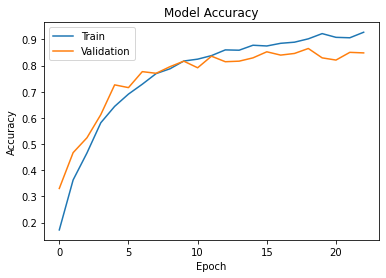

```python
plt.plot(history_vgg16.history['accuracy'])
plt.plot(history_vgg16.history['val_accuracy'])
plt.title('Model Accuracy')
plt.ylabel('Accuracy')
plt.xlabel('Epoch')
plt.legend(['Train', 'Validation'], loc='upper left')
plt.show()
```

- The model is genaralizing well but almost overfitting
- The training was stopped early to prevent overfitting

```python
accuracy = new_model.evaluate(X_test, y_test_encoded, verbose=2)
```

```
15/15 - 1s - loss: 0.5253 - accuracy: 0.8484 - 833ms/epoch - 56ms/step
```

```python
# Here we would get the output as probablities for each category
y_pred=new_model.predict(X_test)
```

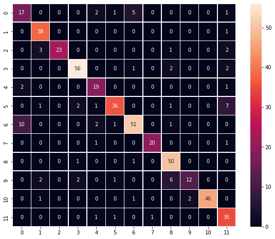

```python
# Obtaining the categorical values from y_test_encoded and y_pred
y_pred_arg=np.argmax(y_pred,axis=1)
y_test_arg=np.argmax(y_test_encoded,axis=1)

# Plotting the Confusion Matrix using confusion matrix() function which is also predefined tensorflow module
confusion_matrix = tf.math.confusion_matrix(y_test_arg,y_pred_arg)
f, ax = plt.subplots(figsize=(10, 8))
sns.heatmap(
    confusion_matrix,
    annot=True,
    linewidths=.4,
    fmt="d",
    square=True,
    ax=ax
)
plt.show()
```

- According to the confusion matrix and accuracy curve, the VGG16 model outperforms Model-2.
- Thus we can say that Model-3 is our best model and we can use this model to predict and visualize some test images.